# Activity 3: Intro to data cleaning and QA/QC

Heather Kropp

#### *GEOG 331: Environmental Data Science, Colgate University*

## Instructions

There are 10 questions to this activity. Save your answers in word document that you will hand in on Moodle using a .pdf extension. Keep your script file in your GitHub folder and make sure that all changes are pushed to GitHub. Code for all questions should be clearly commented with the question number. You will include a link to your script file as a part of your final question in this activity. The assignment is worth 30 points.

## Learning objectives

#### 1. make tests for code in R

#### 2. learn basic data cleaning and QA/QC measures

#### 3. use packages in R

#### 4. learn how to do data QAQC

## Testing your code

The first step in QA/QC is making sure your code is reliable. The concept of testing code for errors or mistaken assumptions is common in programming. For data science and statistical computing, testing code is very open ended and often underutilized. Its a good habit to get into. In R there is no built in function for evaluating a statement and returning an error message. Here you will learn to create your own **function**. In general creating functions is helpful when you want to repeatedly use a few lines of codes or calculations. Let’s create a function called *assert* (python users, you will be used to this function) that checks whether a logical statement is true and returns an error message if it is false.

```r
#create a function. The names of the arguements for your function will be in parentheses. Everything in curly brackets will be run each time the function is run.
assert <- function(statement,err.message){
  #if evaluates if a statement is true or false for a single item
  if(statement == FALSE){
    print(err.message)
  }

}

#check how the statement works
#evaluate a false statement
assert(1 == 2, "error: unequal values")
```

```
## [1] "error: unequal values"
```

```r
#evaluate a true statement
assert(2 == 2, "error: unequal values")
#set up assert to check if two vectors are the same length
a <- c(1,2,3,4)
b <- c(8,4,5)
assert(length(a) == length(b), "error: unequal length")
```

```
## [1] "error: unequal length"
```

This kind of test is helpful for checking that your code or data is functioning as you expect. For example, you may want to check that different data objects have the properties you expect or your caculations are producing the right values. Once successful, these tests may not seem necessary to keep in your code. However, they are because it shows that you are checking the accuracy of your code. It also is good for keeping track of what you checked for versus what you may have missed.

## Understanding the nature of your QA/QC

A couple of faculty in the geography department are interested in understanding the impact of invasive species on the water balance on Colgate’s Bewkes reserve. As a part of their research, they installed a weather station and a soil moisture and temperature sensor. You have been hired as the project data scientist to manage their data. Your first task is do the data QA/QC and make a plot of the data. An ATMOS 41 (Meter Environment, Pullman WA) weather station was installed in June 2018. The weather sensor and datalogger is shown below.

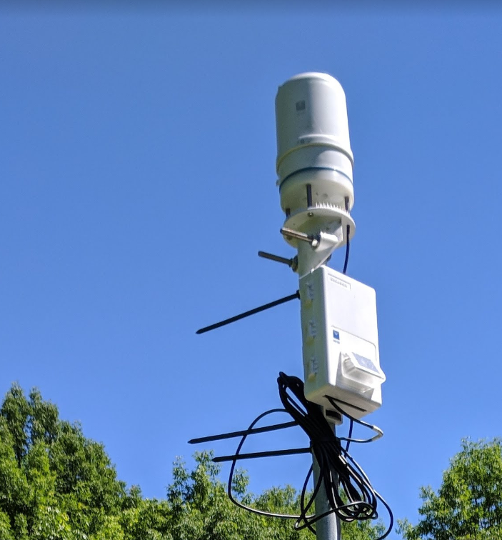

The user manual of the sensor is included in the activity 3 data folder on the server. There is also a 5TM soil sensor that was also installed and the manual can be found in the data folder too. The manual has a throughout description of the sensor accuracy and operating conditions. You’ll notice that there are quality assurance procedures built into the sensor datalogging, and much of the quality assurance is built in for you. Open up *20635_ATMOS41_Manual_Web.pdf*. You’ll notice the first few pages have operation instructions. Section 3.1 has information on the resolution and accuracy of each measurement.

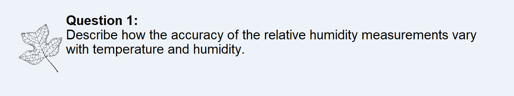

The geography faculty are particularily interested in looking at air temperature, wind speed, precipitation, soil moisture, and soil temperature. Scroll down to section *3.3 Anemometer*. An anemometer is a wind speed sensor. Read through the description of the sensor. You’ll notice that as the datalogger collects data, it is programed to include a degree of quality assurance.

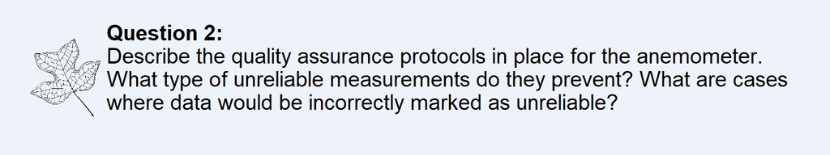

Finish reading through sections 3.4 - 3.6 to understand the nature of data collection for other measurements that you will be working with. Think about any limitations in the measurements. Now that you are more familar with the measurements, read in the data. The *bewkes_weather.csv* is formatted a little different than what you are used to. The first row has column names that describe the type of measurement. The second row indicates the name of the instrument used to collect data in that column. The third row provides units for each measurement. For reading data into a dataframe, we really need a set format. The first row is usually headers (column names) if there are any. In the second row, the data begins. R will automatically make an assumption about the type of data in each column based on all data observations beginning after a header. That means if there are characters in rows 2, 3 and numbers in the rest of the rows, R will default to treating the data as either a character or a factor. This is problematic when you want to only work with the numbers. This means that we will have to read in the csv in a couple of steps.The other problem is that the datalogger stores **NA** as **#N/A**. We’ll want to specify this in our file so that R knows how to deal with these values.

```r
#read in the data file
#skip the first 3 rows since there is additional column info
#specify the the NA is designated differently
datW <- read.csv("y:\\Students\\hkropp\\a03\\bewkes_weather.csv",
                na.strings=c("#N/A"), skip=3, header=FALSE)
#preview data
print(datW[1,])
```

```
##                V1  V2 V3 V4 V5  V6  V7   V8   V9  V10   V11   V12  V13
## 1 6/12/2018 11:30 859  0  0  0 354 0.9 4.24 22.2 0.44 96.46 0.104 21.2
```

```r
#get sensor info from file
# this data table will contain all relevent units
sensorInfo <-   read.csv("y:\\Students\\hkropp\\a03\\bewkes_weather.csv",
                na.strings=c("#N/A"), nrows=2)

print(sensorInfo)
```

```
##   timestamp                     solar.radiation
## 1   Records ATMOS 41 All-in-one Weather Station
## 2 m/d/Y H:M                     W per m squared
##                         precipitation                  lightning.acvitivy
## 1 ATMOS 41 All-in-one Weather Station ATMOS 41 All-in-one Weather Station
## 2                                 mm                                   NA
##                    lightning.distance                            wind.dir
## 1 ATMOS 41 All-in-one Weather Station ATMOS 41 All-in-one Weather Station
## 2                                  km                             degrees
##                            wind.speed                          gust.speed
## 1 ATMOS 41 All-in-one Weather Station ATMOS 41 All-in-one Weather Station
## 2                      m.s Wind Speed                      m.s Gust Speed
##                       air.temperature                      relative.humid
## 1 ATMOS 41 All-in-one Weather Station ATMOS 41 All-in-one Weather Station
## 2                                   C                          proportion
##                  atmospheric.pressure                soil.moisture
## 1 ATMOS 41 All-in-one Weather Station            5TM Moisture/Temp
## 2                                 kPa meters cubed per meter cubed
##           soil.temp
## 1 5TM Moisture/Temp
## 2         degrees C
```

You’ll see we have the data frames are now configured properly and you can find the column names, units, instrument type, for the sensors in *sensorInfo*. The last step is to make sure the dataframe with all of the observations, *datW*, has the column names from the original file. You can get those from *sensorInfo*.

```r
#get column names from sensorInfo table
# and set weather station colnames  to be the same
colnames(datW) <-   colnames(sensorInfo)
#preview data
print(datW[1,])
```

```
##         timestamp solar.radiation precipitation lightning.acvitivy
## 1 6/12/2018 11:30             859             0                  0
##   lightning.distance wind.dir wind.speed gust.speed air.temperature
## 1                  0      354        0.9       4.24            22.2
##   relative.humid atmospheric.pressure soil.moisture soil.temp
## 1           0.44                96.46         0.104      21.2
```

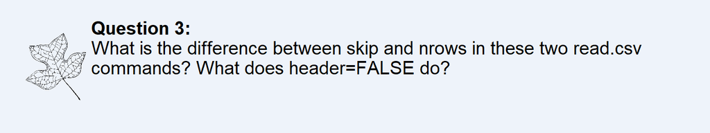

## Data QA/QC

Here our quality assurance will consist of making sure we don’t have any abnormal measurements or use data from outside of the capabilities of the sensor. We will also ensure that any aggregated measures of the half hourly data (e.g. daily average) don’t have too little measurements to create bias. For quality control, we will covert suspect or unreliable measurements to a NA.

### *Using packages*

First, you need to reorganize the date and time in the timestamp to better work with the data more. Last activity, you learned how to work with date formatting. There is a **package** called *lubridate* that has helpful functions for working with dates and times in R. **Packages** contain a suite of related functions that are not available in base R. These functions are useful to enough people to make them available, but they aren’t considered a fundamental enough function to include in the base R. There are currently over 10,000 packages on CRAN (network that makes R available). It would take up a lot of space to download all of these packages and many of these packages may use the same name for functions that perform differently. This is why all of the functons in these packages are not readily available for base R. However, some functions in these additonal packages can be useful and you will want to use them in your script when necessary. The first step is making sure you install the package on your local computer. You only need this command if you have never installed the package on the computer or you recently updated your version of R. On the Colgate computers, you will be asked to use a local directory. That is a good option here.

```r
#use install.packages to install lubridate
install.packages(c("lubridate"))
#it is helpful to comment this line after you run this line of code on the computer
#and the package installs. You really don't want to do this over and over again.
```

Each time you want to use a package for your code, you will need to load the package to your current working environment. You only want to load a package when you are going to use it. This will help minimize any conflicts between function names. You use the **library** function to load a package to your R working environment. You use this function with every script that uses the packages, each time you run the code for the script.

```r
library(lubridate)
```

### *Working with dates*

Lubridate is helpful for handling date and time data and creating standardized formats. Let’s use lubridate to standardize both the date and time. You can always find a description of all of the functions in R by searching for the package and finding the pdf of the package description from CRAN. Below is an example of the description for a function that parses dates and times. You use the name of the function to indicate the format of your time.

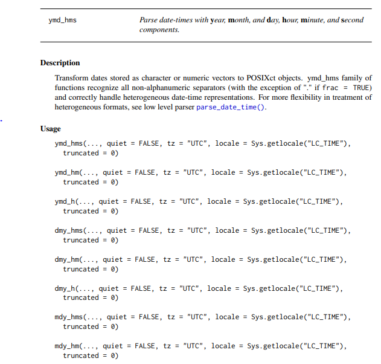

The date is formated *m/d/Y H:M*, and for this function you just need to indicate the order but no othe formatting.

```r
#convert to standardized format
#date format is m/d/y
dates <- mdy_hm(datW$timestamp, tz= "America/New_York")
```

Now that the date is standardized, we can use some helpful functions from lubridate that I like to use. The *doy* function calculates the continuous day of year. For example, January 1st is doy = 1 and December 31 is doy = 365 during a non-leap year. I find this very helpful for plotting and occasionally for calculations involving time. Other helpful measures include an isolated hour measurement and decimal day of year which includes the hours within day of year.

```r
#calculate day of year
datW$doy <- yday(dates)
#calculate hour in the day
datW$hour <- hour(dates) + (minute(dates)/60)
#calculate decimal day of year
datW$DD <- datW$doy + (datW$hour/24)
#quick preview of new date calcualtions
datW[1,]
```

```
##         timestamp solar.radiation precipitation lightning.acvitivy
## 1 6/12/2018 11:30             859             0                  0
##   lightning.distance wind.dir wind.speed gust.speed air.temperature
## 1                  0      354        0.9       4.24            22.2
##   relative.humid atmospheric.pressure soil.moisture soil.temp doy hour
## 1           0.44                96.46         0.104      21.2 163 11.5
##         DD
## 1 163.4792
```

You’ll see in the preview above that an observation on June 12 at 11:30 is on doy 163, at hour 11.5, and is actually at 163.479 when we consider the hours into the doy.

### *Checking missing data*

As you read in the manual, there are many quality control measurements that are built into the sensor datalogger. The data logger may indicate that the data from a sensor is an NA if it considers it to be in an unreliable range. Let’s start by taking a look at how much data we are missing. If there is too much data missing, the researchers need to go check that their equipment is installed properly and still functioning.

You can run a line of code to help do an initial check for missing data. I’ve mentioned in class that R doesn’t deal with NA’s like a character or a number. NA is in it’s own special class. You’ll need to use the functions in R specifically designed for NAs. The **is.na** function is meant to return a TRUE/FALSE answer where TRUE indicates a NA is present. The **which** function indicates all elements in the vector where the items in the function return a TRUE value. If you remember from last class **length** returns the length of the vector. When all three statements are used together, the result will be the number of NAs present in each column of data. Let’s look at the variables the researchers are interested in.

```r
#see how many values have missing data for each sensor observation
#air temperature
length(which(is.na(datW$air.temperature)))
```

```
## [1] 0
```

```r
#wind speed
length(which(is.na(datW$wind.speed)))
```

```
## [1] 0
```

```r
#precipitation
length(which(is.na(datW$precipitation)))
```

```
## [1] 0
```

```r
#soil temperature
length(which(is.na(datW$soil.moisture)))
```

```
## [1] 707
```

```r
#soil moisture
length(which(is.na(datW$soil.temp)))
```

```
## [1] 707
```

You’ll notice there is no missing data for the weather station sensors, so no measurements were considered unreliable and there was no sensor failure. However there are 707 missing values from the soil sensor. That’s a lot of missing data. Let’s make a plot of it so you can go ask the researchers for more information. It will be helpful to plot the decimal day of year and soil moisture observations. This will help you assess what might be going on with the soil sensor.

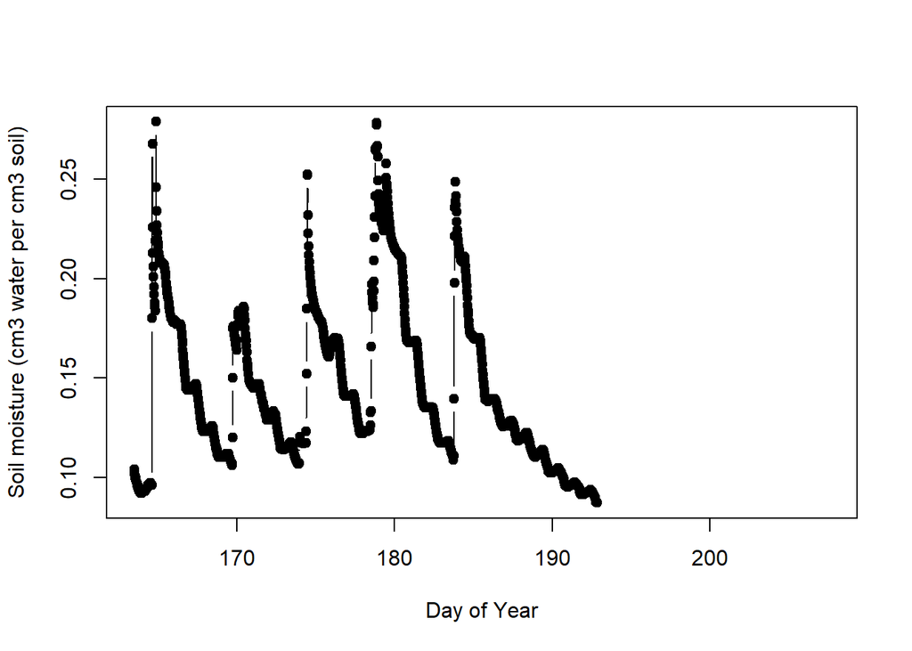

```r
#make a plot with filled in points (using pch)
#line lines
plot(datW$DD, datW$soil.moisture, pch=19, type="b", xlab = "Day of Year",
     ylab="Soil moisture (cm3 water per cm3 soil)")
```

You’ll see the NA are not plotted and the data abruptly stops in the second week of July. You’ll want to see if you can find out more info from the researchers to find out what might be going on and whether there might be any concerns about the other measurements prior to the missing data. First you’ll want to QA/QC the rest of the data to see if there are any other issues.

## Setting up tests for QA/QC

### *Visual checks*

There are many ways to do QA/QC. For small datasets, an initial check on a plot can often capture a lot of elements for QA/QC. However, for large datasets, a visual check of the data is impossible and insufficient. More quantitative measures can also help reinforce the expectations and assumptions associated with the data.

Let’s start with air temperature. Looking at a plot will help familarize you with the data.

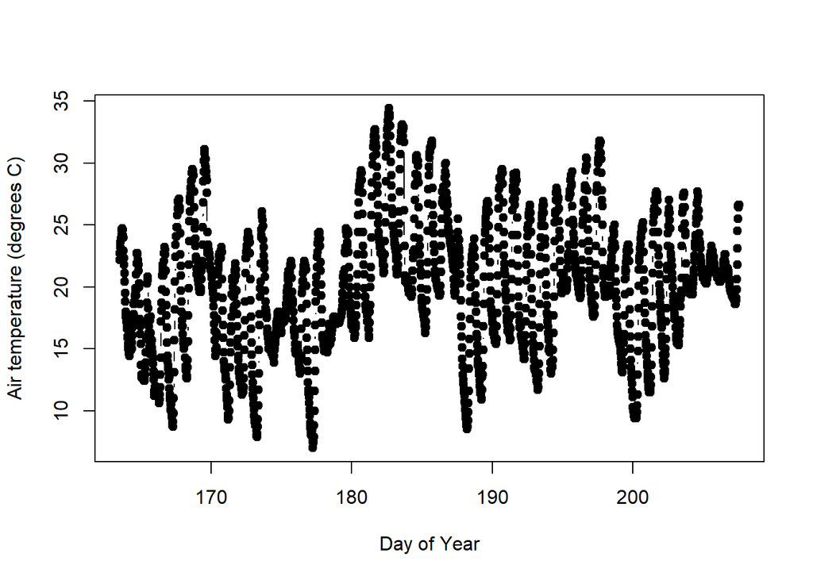

```r
#make a plot with filled in points (using pch)
#line lines
plot(datW$DD, datW$air.temperature, pch=19, type="b", xlab = "Day of Year",
     ylab="Air temperature (degrees C)")
```

We can see that the data looks reasonable. We don’t have any extreme spikes in observations and the fluctions look like typical daily variation. Watch for odd repeating patterns, extreme jumps in values in a short period of time (1-2 hours), or unrealistic values. If there are extreme jumps in values, it would be helpful to look at metrics like the change in temperature with each half hour. We don’t have to worry about that here because the datalogger does a good job of quality assurance. Before we go any further, let’s establish how to convert unreliable data to NA. We’ll use an example that isn’t a problem in our data just to illustrate the code. In this summer dataset, I know that I should not observe any air temperature values below freezing. I will specify that any values below freezing should be considered as missing data for an example.

```r
#I'm going to make a new column to work with that indicates that I am conducting QAQC
#because overwriting values should be done cautiously and can lead to confusing issues.
#It can be particularily confusing when you are just learning R.
#Here I'm using the ifelse function
#the first argument is a logical statement to be evaluated as true or false on a vector
#the second argument is the value that my air.tempQ1 column will be given if the statement
#is true. The last value is the value that will be given to air.tempQ1 if the statement is false.
#In this case it is just given the air temperature value
datW$air.tempQ1 <- ifelse(datW$air.temperature < 0, NA, datW$air.temperature)
```

### *Realistic values*

The next step is to check the range of the more extreme values. We want to make sure the data range that is collected is realistic. There are a couple of measurements that look very high and very low. Let’s investigate. The **quantile** function returns the values of data for a given frequency of data. The 50% quantile is the value in the data where 50% of the values are above it and 50% of the values are below it. This is the **median**. The 0% quantile means that no data occurs below that value and that value is the **minimum** . The 100% quantile means that all data occurs below the value and that value is the **maximum**.

```r
#check the values at the extreme range of the data
#and throughout the percentiles
quantile(datW$air.tempQ1)
```

```
##   0%  25%  50%  75% 100%
##  7.0 16.2 20.1 23.3 34.4
```

Some statisticians and data scientists like to filter extreme values using quantiles. For example, some outlier tests remove values that occur less than 5% or 1% of the time. These tests should be used with caution and limited to data that appears to be suspect with extreme spikes. In weather data, record highs or lows can often be reliablely measured by instruments. We don’t want to filter them out just because these values don’t occur very often. In fact, these extreme values are often of interest for many different applications.

The maximum and minimum values in this dataset seem infrequent for this area, but not impossible. Since air temperature is corrected with solar radiation and wind data, extreme values in caculations can often occur due to numerical artifacts of the way the calculations can be structured. It would be good to check that these extreme values really are accurate. Unfortunately, there are no half hourly weather stations to compare the data to nearby that can be readily downloaded for analysis. However, you can find a visualization of historic weather data by day. Let’s do the comparison. First, let’s take a look at the days that have these extreme observations.

```r
#look at days with really low air temperature
datW[datW$air.tempQ1 < 8,]
```

```
##          timestamp solar.radiation precipitation lightning.acvitivy
## 470 6/22/2018 6:00              12             0                  0
## 660 6/26/2018 5:00               0             0                  0
## 661 6/26/2018 5:30               1             0                  0
## 662 6/26/2018 6:00               7             0                  0
## 663 6/26/2018 6:30              17             0                  0
## 664 6/26/2018 7:00              26             0                  0
##     lightning.distance wind.dir wind.speed gust.speed air.temperature
## 470                  0      329       0.31       0.85             7.9
## 660                  0      318       0.35       0.61             7.5
## 661                  0      318       0.38       0.67             7.0
## 662                  0      317       0.39       0.61             7.4
## 663                  0      326       0.31       0.64             7.5
## 664                  0      336       0.27       0.46             7.9
##     relative.humid atmospheric.pressure soil.moisture soil.temp doy hour
## 470           0.85                96.00     0.1160974      9.61 173  6.0
## 660           0.85                96.93     0.1409786      9.50 177  5.0
## 661           0.88                96.94     0.1409786      9.37 177  5.5
## 662           0.86                96.95     0.1409786      9.33 177  6.0
## 663           0.86                96.96     0.1411936      9.45 177  6.5
## 664           0.88                96.96     0.1411936      9.67 177  7.0
##           DD air.tempQ1
## 470 173.2500        7.9
## 660 177.2083        7.5
## 661 177.2292        7.0
## 662 177.2500        7.4
## 663 177.2708        7.5
## 664 177.2917        7.9
```

```r
 #look at days with really high air temperature
datW[datW$air.tempQ1 > 33,]
```

```
##          timestamp solar.radiation precipitation lightning.acvitivy
## 918 7/1/2018 14:00             915             0                  0
## 919 7/1/2018 14:30             896             0                  0
## 920 7/1/2018 15:00             870             0                  0
## 921 7/1/2018 15:30             826             0                  0
## 922 7/1/2018 16:00             761             0                  0
## 923 7/1/2018 16:30             691             0                  0
## 924 7/1/2018 17:00             611             0                  0
## 966 7/2/2018 14:00             804             0                  0
##     lightning.distance wind.dir wind.speed gust.speed air.temperature
## 918                  0       57       0.56       1.20            33.4
## 919                  0       70       0.67       1.83            33.6
## 920                  0       74       0.61       1.88            34.0
## 921                  0       77       0.64       2.33            34.1
## 922                  0       66       0.56       1.52            34.4
```

[output cut: 21 more lines]

Go to https://www.wunderground.com/history/daily/us/ny/hamilton/KNYHAMIL11/date/2019-11-4 and find the dates for the low temperature value and the high temperature. See if the station close to Hamilton on the website had similar values.

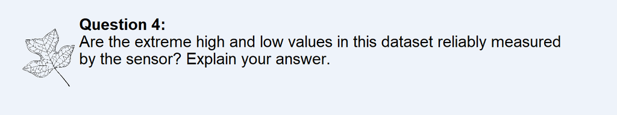

### *Measurements outside of sensor capabilities*

If you continue reading in the manual, you will find the section pictured below that explains that measurements (mainly wind and air temperature) may be unreliable when there is heavy wind and strong rain.

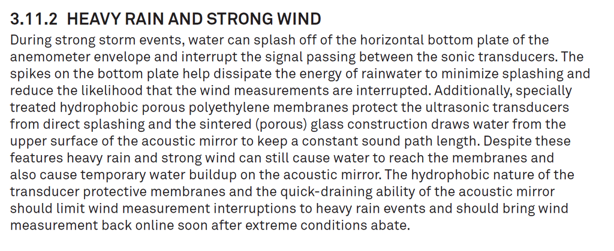

In this area, these kinds of events in the summer typically occur as thunderstorms. Since the wind sensor may be unreliable during this time, let’s use precipitation and the lightning sensor to mark any air temperature and wind data that would be unreliable. First let’s take a look at both values on the same plot.

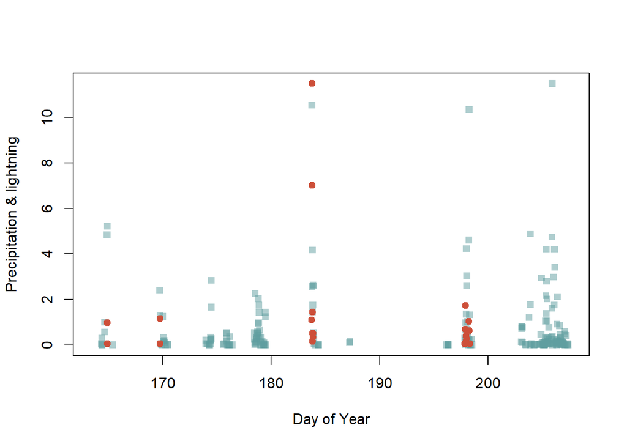

[figure not shown]

```r
#plot precipitation and lightning strikes on the same plot
#normalize lighting strikes to match precipitation
lightscale <- (max(datW$precipitation)/max(datW$lightning.acvitivy)) * datW$lightning.acvitivy
#make the plot with precipitation and lightning activity marked
#make it empty to start and add in features
plot(datW$DD , datW$precipitation, xlab = "Day of Year", ylab = "Precipitation & lightning",
        type="n")
#plot precipitation points only when there is precipitation
#make the points semi-transparent
points(datW$DD[datW$precipitation > 0], datW$precipitation[datW$precipitation > 0],
        col= rgb(95/255,158/255,160/255,.5), pch=15)

#plot lightning points only when there is lightning
points(datW$DD[lightscale > 0], lightscale[lightscale > 0],
        col= "tomato3", pch=19)
```

You can see from the plot there are points when there is lightning and high rain. Let’s filter all values with lightning that coincides with rainfall greater than 2mm or only rainfall over 5 mm.

```r
#filter out storms in wind and air temperature measurements
# filter all values with lightning that coincides with rainfall greater than 2mm or only rainfall over 5 mm.
#create a new air temp column
datW$air.tempQ2 <- ifelse(datW$precipitation  >= 2 & datW$lightning.acvitivy >0, NA,
                    ifelse(datW$precipitation > 5, NA, datW$air.tempQ1))
```

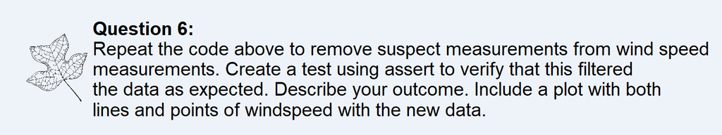

## Finishing your QA/QC

You talked to the researchers about the missing soil temperature and moisture data. They looked at their field notes and have more information. They noted that in mid-July the weather station had been tampered with. The soil moisture and temperature sensor was found lying on top of the ground and the cable pulled out of the datalogger. If the soil moisture and temperature sensor loses contact with the ground, the measurements will be unreliable. Sudden changes in the sensor position in the ground are marked by dramatic changes in soil temperature and moisture. Although its likely something pulled out the sensor from the ground simultaneously unplugging the cable, you will want to check that this is a reasonable expectation.

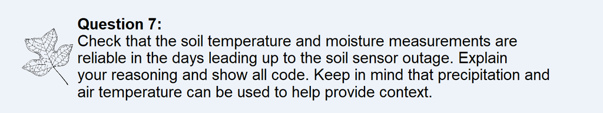

## Providing results to the researchers

The researchers would like you to help generate a final report of the weather station data. Complete the following questions below.

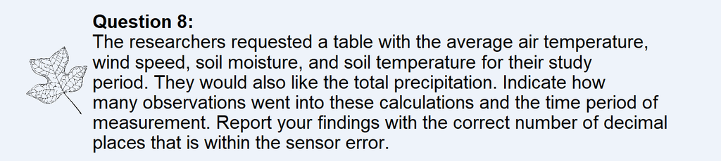

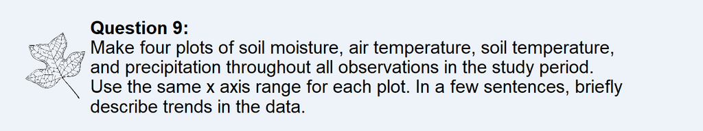

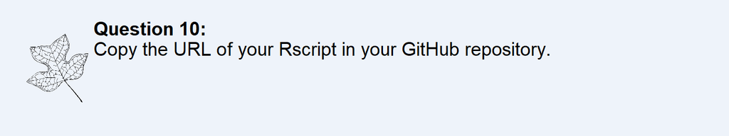